# CM3015 Machine Learning and Neural Networks

## Midterm Paper

Student ID: 220516639  
Name: Teo Jia En  
Date of Submission: 5th January 2025

## Abstract

This report is written in fulfilment of CM3015 (Machine Learning and Neural Networks) midterm coursework.

The purpose of this project is to find the best Machine Learning (ML) model for the classification task of determining whether a customer will default on the payment of credit card.

To this end, the paper will include a comprehensive analysis of how different ML algorithms perform on the same dataset.

Specific algorithms used are:

- K-Nearest Neighbours
- Naive Bayes
- Logistic Regression
- Decision Tree

# 1. Introduction

### Aim and objectives

The aim of the project is to find the best Classification Machine Learning model to predict the probability of default of credit card clients. We will compare the performance of K-Nearest Neighbours (KNN), Naive Bayes, Logistic Regression and Decision Trees. Three algorithms - KNN, Naive Bayes annd Logistic Regression will be implemented from scratch.

A model will predict whether a default will occur in the following month, with Yes = 1 and No = 0.

The project will include cross-validation and hyperparameter tuning. By the end of this project, we will have the optimal model parameters and the best classifier.

This project will contribute to the discourse by demystifying foundational algorithms and basic techniques that underpins modern credit default prediction systems. This knowledge will lay the groundwork for exploration into more complex prediction methods.

### Dataset

The dataset used, named 'Default of Credit Card Clients' is acquired from the UC Irvine Machine Learning Repository. It was donated by Yeh and Lien in January 2016. [1] It contains 30,000 instances of Taiwanese credit card clients and 23 features. It is licensed under Creative Commons Attribution 4.0 International (CC BY 4.0).

This dataset is chosen for its high usability. The multivariate dataset reflects real-world conditions where relationships between variables are complex and diverse. The features selected has also proven effective in its predictive accuracy.

### Ethical considerations

Algorithm bias occurs when the models produce biased results that perpetuate human biases and systemic inequality. This is especially prevelant in training datasets about bank loans, where overrepresentation or underrepresentation of disadvantaged groups result in discriminatory outcomes. [2] This project will not examinine or detect such bias, as it falls outside the scope of the coursework.

As such, ML models produced by this project should not be used in place of an authority on the subject.

In addition, any future works have to comply with the updated Conditions of Use by the owner of the dataset.

# 2. Dataset pre-processing

In this section, we will prepare the data by handling any missing values. We will perform scaling to ensure optimal performance of distance-based algorithms, used by classifiers such as KNN.

```python
"""
LIBRARIES USED FOR THIS PROJECT
"""
import numpy as np # for data manipulation
import pandas as pd # for data exploration and processing


# to download the dataset
!pip install ucimlrepo

# to import the method used to import datasets
from ucimlrepo import fetch_ucirepo

# to fetch the dataset, which has an id of 350
default_of_credit_card_clients = fetch_ucirepo(id=350)

import seaborn as sns
import matplotlib.pyplot as plt

# data (loaded as pandas dataframes)
X = default_of_credit_card_clients.data.features
y = default_of_credit_card_clients.data.targets

import warnings
warnings.filterwarnings('ignore')
```

## 2.1 Cursory look at dataset

```python
X.describe()
```

|  | X1 | X2 | X3 | X4 | X5 | X6 | X7 | X8 | X9 | X10 | ... | X14 | X15 | X16 | X17 | X18 | X19 | X20 | X21 | X22 | X23 |
| --- | --- | --- | --- | --- | --- | --- | --- | --- | --- | --- | --- | --- | --- | --- | --- | --- | --- | --- | --- | --- | --- |
| count | 30000.000000 | 30000.000000 | 30000.000000 | 30000.000000 | 30000.000000 | 30000.000000 | 30000.000000 | 30000.000000 | 30000.000000 | 30000.000000 | ... | 3.000000e+04 | 30000.000000 | 30000.000000 | 30000.000000 | 30000.000000 | 3.000000e+04 | 30000.00000 | 30000.000000 | 30000.000000 | 30000.000000 |
| mean | 167484.322667 | 1.603733 | 1.853133 | 1.551867 | 35.485500 | -0.016700 | -0.133767 | -0.166200 | -0.220667 | -0.266200 | ... | 4.701315e+04 | 43262.948967 | 40311.400967 | 38871.760400 | 5663.580500 | 5.921163e+03 | 5225.68150 | 4826.076867 | 4799.387633 | 5215.502567 |
| std | 129747.661567 | 0.489129 | 0.790349 | 0.521970 | 9.217904 | 1.123802 | 1.197186 | 1.196868 | 1.169139 | 1.133187 | ... | 6.934939e+04 | 64332.856134 | 60797.155770 | 59554.107537 | 16563.280354 | 2.304087e+04 | 17606.96147 | 15666.159744 | 15278.305679 | 17777.465775 |
| min | 10000.000000 | 1.000000 | 0.000000 | 0.000000 | 21.000000 | -2.000000 | -2.000000 | -2.000000 | -2.000000 | -2.000000 | ... | -1.572640e+05 | -170000.000000 | -81334.000000 | -339603.000000 | 0.000000 | 0.000000e+00 | 0.00000 | 0.000000 | 0.000000 | 0.000000 |
| 25% | 50000.000000 | 1.000000 | 1.000000 | 1.000000 | 28.000000 | -1.000000 | -1.000000 | -1.000000 | -1.000000 | -1.000000 | ... | 2.666250e+03 | 2326.750000 | 1763.000000 | 1256.000000 | 1000.000000 | 8.330000e+02 | 390.00000 | 296.000000 | 252.500000 | 117.750000 |
| 50% | 140000.000000 | 2.000000 | 2.000000 | 2.000000 | 34.000000 | 0.000000 | 0.000000 | 0.000000 | 0.000000 | 0.000000 | ... | 2.008850e+04 | 19052.000000 | 18104.500000 | 17071.000000 | 2100.000000 | 2.009000e+03 | 1800.00000 | 1500.000000 | 1500.000000 | 1500.000000 |
| 75% | 240000.000000 | 2.000000 | 2.000000 | 2.000000 | 41.000000 | 0.000000 | 0.000000 | 0.000000 | 0.000000 | 0.000000 | ... | 6.016475e+04 | 54506.000000 | 50190.500000 | 49198.250000 | 5006.000000 | 5.000000e+03 | 4505.00000 | 4013.250000 | 4031.500000 | 4000.000000 |
| max | 1000000.000000 | 2.000000 | 6.000000 | 3.000000 | 79.000000 | 8.000000 | 8.000000 | 8.000000 | 8.000000 | 8.000000 | ... | 1.664089e+06 | 891586.000000 | 927171.000000 | 961664.000000 | 873552.000000 | 1.684259e+06 | 896040.00000 | 621000.000000 | 426529.000000 | 528666.000000 |

8 rows × 23 columns

In the code block above, we call the describe() method on the Pandas DataFrame to generate descriptive statistics that summarise central tendency and distribution of the features. We can see that there are 30000 data points for each of the features. Notably, we can see that the features are of different scales - the mean for X1 is 167,484 while the mean for X2 is 1.6. This implies a need for scaling as part of the pre-processing step.

```python
# Check whether the features has any missing values
X.isnull().values.any()
```

```
False
```

In the code above, we check if there are any missing values. Missing values have to be removed to ensure the integrity of the dataset, and to prevent skewed predictions by our machine learning models. Fortunately, there are no missing values in this dataset.

## 2.3 Removing outliers with Inter Quartile Range (IQR)

Classification models such as NaiveBayes and KNN are sensitive to outliers - an anamalous data point that deviates significantly from the rest. A single outlier will dramatically change class boundaries, which leads to inaccurate models. Hence, to ensure that the ML models are not leveraged towards outlier data points, outliers in the dataset must be removed. [3]

```python
import seaborn as sns
import numpy as np
sns.set_style("white")
```

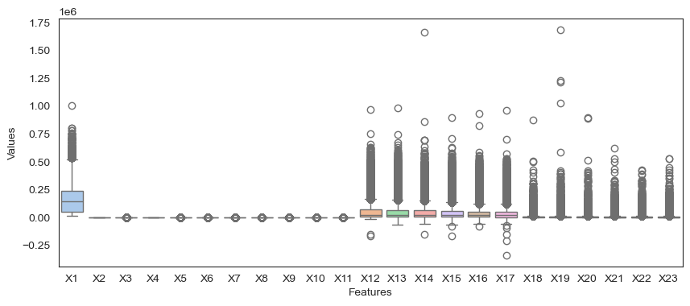

```python
fig, ax =  plt.subplots(figsize=(10,4))
# sns.set_theme(rc={'figure.figsize':(10,4)})
sns.boxplot(data = X, orient = "v", palette = "pastel", ax = ax)
ax.set(xlabel='Features', ylabel='Values');
```

In order to identify outliers, we use the IQR (Inter-quartile Range) method to identify the data that falls outside our intended scope of observations. We first find the midpoint of the dataset and define Quartile 1 and Quartile 3. We then determine the extreme, caculated by adding and subtracting 1.5 of the iqr. [4]

```python
## Reference: https://www.geeksforgeeks.org/detect-and-remove-the-outliers-using-python/

pd.options.mode.chained_assignment = None

# for each feature in the dataset (23 features)
for feature in X.columns:
    # calculate the 15th percentile
    quartile1 = np.percentile(X[feature],15, method = 'midpoint')

    # calculate the 85th percentile
    quartile3 = np.percentile(X[feature],85, method = 'midpoint')

    # calculate the IQR
    iqr = quartile3 - quartile1

    # calculate the lower bound (extreme below which data will be discarded)
    lower_bound = quartile1 - 1.5 * iqr

    # calculate the uper bound (extreme above which data will be discarded)
    upper_bound = quartile3 + 1.5 * iqr

    # identify the row index where there exists an outlier, determined by upper and lower bound
    lower_array = np.where(X[feature] <= lower_bound)[0] # index of bottom outliers
    upper_array = np.where(X[feature] >= upper_bound)[0] # index of top outliers


    # using try and except to
    try:
        # Create a combined DataFrame for easier indexing
        df = pd.concat([X, y], axis=1)

        # Identify rows to drop based on conditions
        rows_to_drop = df.index[(df < bottom_bound) | (df > top_bound)].tolist()

        # Drop the identified rows from both X and y
        X = X.drop(index=rows_to_drop)
        y = y.drop(index=rows_to_drop)


    except:
        pass

print(X.shape, y.shape) # to check that the number of rows are equal
```

```
(30000, 23) (30000, 1)
```

## 2.4 Scaling

Scaling of features is an important pre-processing step that transforms features to a common scale. This normalises the distribution and magnitude of features and ensure that each feature contribute equally to the model.

Feature scaling is especially important in ML models like KNN classifiers, which utilises distance-based calculations for its predictions

Reference: https://medium.com/@shivanipickl/what-is-feature-scaling-and-why-does-machine-learning-need-it-104eedebb1c9

```python
from sklearn.model_selection import train_test_split
from sklearn.preprocessing import StandardScaler
import pandas as pd

# Split the data into training and test

X_train, X_test, y_train, y_test = train_test_split(X, y, test_size=0.4, random_state=42, stratify=y)
# X_val, X_test, y_val, y_test = train_test_split(X_temp, y_temp, test_size=0.5, random_state=42, stratify=y_temp)

# scaler
scaler = StandardScaler()
scaler.fit(X_train)
X_train_scaled = pd.DataFrame(scaler.transform(X_train))
X_test_scaled = pd.DataFrame(scaler.transform(X_test))
```

```python
print(f"Shape of training data is {y_train.shape}")
print(f"Shape of testing data is {y_test.shape}")
```

```
Shape of training data is (18000, 1)
Shape of testing data is (12000, 1)
```

```python
from sklearn.neighbors import KNeighborsClassifier
from sklearn.metrics import accuracy_score

# Classifier without scaling
knn = KNeighborsClassifier(n_neighbors=3)
knn.fit(X_train.values, y_train.values.ravel())
predictions = knn.predict(X_test.values)
accuracy_nonscaled = accuracy_score(y_test.values.ravel(), predictions)
print(f"Accuracy without scaling: {accuracy_nonscaled:.3f}")

# Classifier with scaling
knn_scaled = KNeighborsClassifier(n_neighbors=3)
knn_scaled.fit(X_train_scaled.values, y_train.values.ravel())
scaled_predictions = knn_scaled.predict(X_test_scaled.values)
accuracy_scaled = accuracy_score(y_test.values.ravel(), scaled_predictions)
print(f"Accuracy with scaling: {accuracy_scaled:.3f}")
```

```
Accuracy without scaling: 0.738
Accuracy with scaling: 0.778
```

# 3. Exploratory Data Analysis

In this section, we will do a cursory statistical analysis of the dataset to analyse the balance of the clasess, and determine the evaluation metric we should use for the classifiers. If the dataset is balanced, the accuracy score will b used. If the dataset is imbalanced. The F1 score (or AUC) will be used.

We will then use pair plots, scatter plots and histograms to find how each feature would contribute to the prediction.

## 3.1 Class imbalance

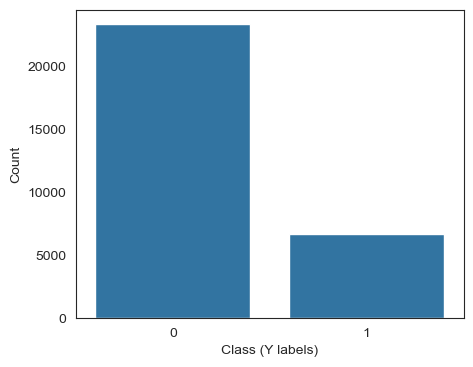

```python
fig, ax =  plt.subplots(figsize=(5,4))
s = y.value_counts().to_frame()
sns.barplot(data = s, x = 'Y', y = 'count', orient = 'v');
ax.set(xlabel='Class (Y labels)', ylabel='Count');
```

```python
y.value_counts()
```

```
Y
0    23364
1     6636
Name: count, dtype: int64
```

https://developers.google.com/machine-learning/crash-course/overfitting/imbalanced-datasets#:~:text=Imbalanced%20datasets%20sometimes%20don%27t,learn%20enough%20about%20positive%20labels.

Since around 20% of the dataset belong to the minority class, this is a mild degree of imbalance. We will train on the original dataset without downsampling or upweighting.

## 3.2 Correlation matrix for features and label

In the following section, we will explore the correlation coefficients between the features and the label. This will show us potential relationships amongst the dataset.

```python
# Convert labels into a dataframe object
y = pd.DataFrame(y, columns = ['Y'])

# Join features and labels to find any correlation
full_df = X
X['Y'] = y

 # plot the correlation matrix between the features and the label
cor_mat = full_df.corr()
cor_mat.style.background_gradient(cmap = 'GnBu')
```

|  | X1 | X2 | X3 | X4 | X5 | X6 | X7 | X8 | X9 | X10 | X11 | X12 | X13 | X14 | X15 | X16 | X17 | X18 | X19 | X20 | X21 | X22 | X23 | Y |
| --- | --- | --- | --- | --- | --- | --- | --- | --- | --- | --- | --- | --- | --- | --- | --- | --- | --- | --- | --- | --- | --- | --- | --- | --- |
| X1 | 1.000000 | 0.024755 | -0.219161 | -0.108139 | 0.144713 | -0.271214 | -0.296382 | -0.286123 | -0.267460 | -0.249411 | -0.235195 | 0.285430 | 0.278314 | 0.283236 | 0.293988 | 0.295562 | 0.290389 | 0.195236 | 0.178408 | 0.210167 | 0.203242 | 0.217202 | 0.219595 | -0.153520 |
| X2 | 0.024755 | 1.000000 | 0.014232 | -0.031389 | -0.090874 | -0.057643 | -0.070771 | -0.066096 | -0.060173 | -0.055064 | -0.044008 | -0.033642 | -0.031183 | -0.024563 | -0.021880 | -0.017005 | -0.016733 | -0.000242 | -0.001391 | -0.008597 | -0.002229 | -0.001667 | -0.002766 | -0.039961 |
| X3 | -0.219161 | 0.014232 | 1.000000 | -0.143464 | 0.175061 | 0.105364 | 0.121566 | 0.114025 | 0.108793 | 0.097520 | 0.082316 | 0.023581 | 0.018749 | 0.013002 | -0.000451 | -0.007567 | -0.009099 | -0.037456 | -0.030038 | -0.039943 | -0.038218 | -0.040358 | -0.037200 | 0.028006 |
| X4 | -0.108139 | -0.031389 | -0.143464 | 1.000000 | -0.414170 | 0.019917 | 0.024199 | 0.032688 | 0.033122 | 0.035629 | 0.034345 | -0.023472 | -0.021602 | -0.024909 | -0.023344 | -0.025393 | -0.021207 | -0.005979 | -0.008093 | -0.003541 | -0.012659 | -0.001205 | -0.006641 | -0.024339 |
| X5 | 0.144713 | -0.090874 | 0.175061 | -0.414170 | 1.000000 | -0.039447 | -0.050148 | -0.053048 | -0.049722 | -0.053826 | -0.048773 | 0.056239 | 0.054283 | 0.053710 | 0.051353 | 0.049345 | 0.047613 | 0.026147 | 0.021785 | 0.029247 | 0.021379 | 0.022850 | 0.019478 | 0.013890 |
| X6 | -0.271214 | -0.057643 | 0.105364 | 0.019917 | -0.039447 | 1.000000 | 0.672164 | 0.574245 | 0.538841 | 0.509426 | 0.474553 | 0.187068 | 0.189859 | 0.179785 | 0.179125 | 0.180635 | 0.176980 | -0.079269 | -0.070101 | -0.070561 | -0.064005 | -0.058190 | -0.058673 | 0.324794 |
| X7 | -0.296382 | -0.070771 | 0.121566 | 0.024199 | -0.050148 | 0.672164 | 1.000000 | 0.766552 | 0.662067 | 0.622780 | 0.575501 | 0.234887 | 0.235257 | 0.224146 | 0.222237 | 0.221348 | 0.219403 | -0.080701 | -0.058990 | -0.055901 | -0.046858 | -0.037093 | -0.036500 | 0.263551 |
| X8 | -0.286123 | -0.066096 | 0.114025 | 0.032688 | -0.053048 | 0.574245 | 0.766552 | 1.000000 | 0.777359 | 0.686775 | 0.632684 | 0.208473 | 0.237295 | 0.227494 | 0.227202 | 0.225145 | 0.222327 | 0.001295 | -0.066793 | -0.053311 | -0.046067 | -0.035863 | -0.035861 | 0.235253 |
| X9 | -0.267460 | -0.060173 | 0.108793 | 0.033122 | -0.049722 | 0.538841 | 0.662067 | 0.777359 | 1.000000 | 0.819835 | 0.716449 | 0.202812 | 0.225816 | 0.244983 | 0.245917 | 0.242902 | 0.239154 | -0.009362 | -0.001944 | -0.069235 | -0.043461 | -0.033590 | -0.026565 | 0.216614 |
| X10 | -0.249411 | -0.055064 | 0.097520 | 0.035629 | -0.053826 | 0.509426 | 0.622780 | 0.686775 | 0.819835 | 1.000000 | 0.816900 | 0.206684 | 0.226913 | 0.243335 | 0.271915 | 0.269783 | 0.262509 | -0.006089 | -0.003191 | 0.009062 | -0.058299 | -0.033337 | -0.023027 | 0.204149 |
| X11 | -0.235195 | -0.044008 | 0.082316 | 0.034345 | -0.048773 | 0.474553 | 0.575501 | 0.632684 | 0.716449 | 0.816900 | 1.000000 | 0.207373 | 0.226924 | 0.241181 | 0.266356 | 0.290894 | 0.285091 | -0.001496 | -0.005223 | 0.005834 | 0.019018 | -0.046434 | -0.025299 | 0.186866 |
| X12 | 0.285430 | -0.033642 | 0.023581 | -0.023472 | 0.056239 | 0.187068 | 0.234887 | 0.208473 | 0.202812 | 0.206684 | 0.207373 | 1.000000 | 0.951484 | 0.892279 | 0.860272 | 0.829779 | 0.802650 | 0.140277 | 0.099355 | 0.156887 | 0.158303 | 0.167026 | 0.179341 | -0.019644 |
| X13 | 0.278314 | -0.031183 | 0.018749 | -0.021602 | 0.054283 | 0.189859 | 0.235257 | 0.237295 | 0.225816 | 0.226913 | 0.226924 | 0.951484 | 1.000000 | 0.928326 | 0.892482 | 0.859778 | 0.831594 | 0.280365 | 0.100851 | 0.150718 | 0.147398 | 0.157957 | 0.174256 | -0.014193 |
| X14 | 0.283236 | -0.024563 | 0.013002 | -0.024909 | 0.053710 | 0.179785 | 0.224146 | 0.227494 | 0.244983 | 0.243335 | 0.241181 | 0.892279 | 0.928326 | 1.000000 | 0.923969 | 0.883910 | 0.853320 | 0.244335 | 0.316936 | 0.130011 | 0.143405 | 0.179712 | 0.182326 | -0.014076 |
| X15 | 0.293988 | -0.021880 | -0.000451 | -0.023344 | 0.051353 | 0.179125 | 0.222237 | 0.227202 | 0.245917 | 0.271915 | 0.266356 | 0.860272 | 0.892482 | 0.923969 | 1.000000 | 0.940134 | 0.900941 | 0.233012 | 0.207564 | 0.300023 | 0.130191 | 0.160433 | 0.177637 | -0.010156 |
| X16 | 0.295562 | -0.017005 | -0.007567 | -0.025393 | 0.049345 | 0.180635 | 0.221348 | 0.225145 | 0.242902 | 0.269783 | 0.290894 | 0.829779 | 0.859778 | 0.883910 | 0.940134 | 1.000000 | 0.946197 | 0.217031 | 0.181246 | 0.252305 | 0.293118 | 0.141574 | 0.164184 | -0.006760 |
| X17 | 0.290389 | -0.016733 | -0.009099 | -0.021207 | 0.047613 | 0.176980 | 0.219403 | 0.222327 | 0.239154 | 0.262509 | 0.285091 | 0.802650 | 0.831594 | 0.853320 | 0.900941 | 0.946197 | 1.000000 | 0.199965 | 0.172663 | 0.233770 | 0.250237 | 0.307729 | 0.115494 | -0.005372 |
| X18 | 0.195236 | -0.000242 | -0.037456 | -0.005979 | 0.026147 | -0.079269 | -0.080701 | 0.001295 | -0.009362 | -0.006089 | -0.001496 | 0.140277 | 0.280365 | 0.244335 | 0.233012 | 0.217031 | 0.199965 | 1.000000 | 0.285576 | 0.252191 | 0.199558 | 0.148459 | 0.185735 | -0.072929 |
| X19 | 0.178408 | -0.001391 | -0.030038 | -0.008093 | 0.021785 | -0.070101 | -0.058990 | -0.066793 | -0.001944 | -0.003191 | -0.005223 | 0.099355 | 0.100851 | 0.316936 | 0.207564 | 0.181246 | 0.172663 | 0.285576 | 1.000000 | 0.244770 | 0.180107 | 0.180908 | 0.157634 | -0.058579 |
| X20 | 0.210167 | -0.008597 | -0.039943 | -0.003541 | 0.029247 | -0.070561 | -0.055901 | -0.053311 | -0.069235 | 0.009062 | 0.005834 | 0.156887 | 0.150718 | 0.130011 | 0.300023 | 0.252305 | 0.233770 | 0.252191 | 0.244770 | 1.000000 | 0.216325 | 0.159214 | 0.162740 | -0.056250 |
| X21 | 0.203242 | -0.002229 | -0.038218 | -0.012659 | 0.021379 | -0.064005 | -0.046858 | -0.046067 | -0.043461 | -0.058299 | 0.019018 | 0.158303 | 0.147398 | 0.143405 | 0.130191 | 0.293118 | 0.250237 | 0.199558 | 0.180107 | 0.216325 | 1.000000 | 0.151830 | 0.157834 | -0.056827 |
| X22 | 0.217202 | -0.001667 | -0.040358 | -0.001205 | 0.022850 | -0.058190 | -0.037093 | -0.035863 | -0.033590 | -0.033337 | -0.046434 | 0.167026 | 0.157957 | 0.179712 | 0.160433 | 0.141574 | 0.307729 | 0.148459 | 0.180908 | 0.159214 | 0.151830 | 1.000000 | 0.154896 | -0.055124 |
| X23 | 0.219595 | -0.002766 | -0.037200 | -0.006641 | 0.019478 | -0.058673 | -0.036500 | -0.035861 | -0.026565 | -0.023027 | -0.025299 | 0.179341 | 0.174256 | 0.182326 | 0.177637 | 0.164184 | 0.115494 | 0.185735 | 0.157634 | 0.162740 | 0.157834 | 0.154896 | 1.000000 | -0.053183 |
| Y | -0.153520 | -0.039961 | 0.028006 | -0.024339 | 0.013890 | 0.324794 | 0.263551 | 0.235253 | 0.216614 | 0.204149 | 0.186866 | -0.019644 | -0.014193 | -0.014076 | -0.010156 | -0.006760 | -0.005372 | -0.072929 | -0.058579 | -0.056250 | -0.056827 | -0.055124 | -0.053183 | 1.000000 |

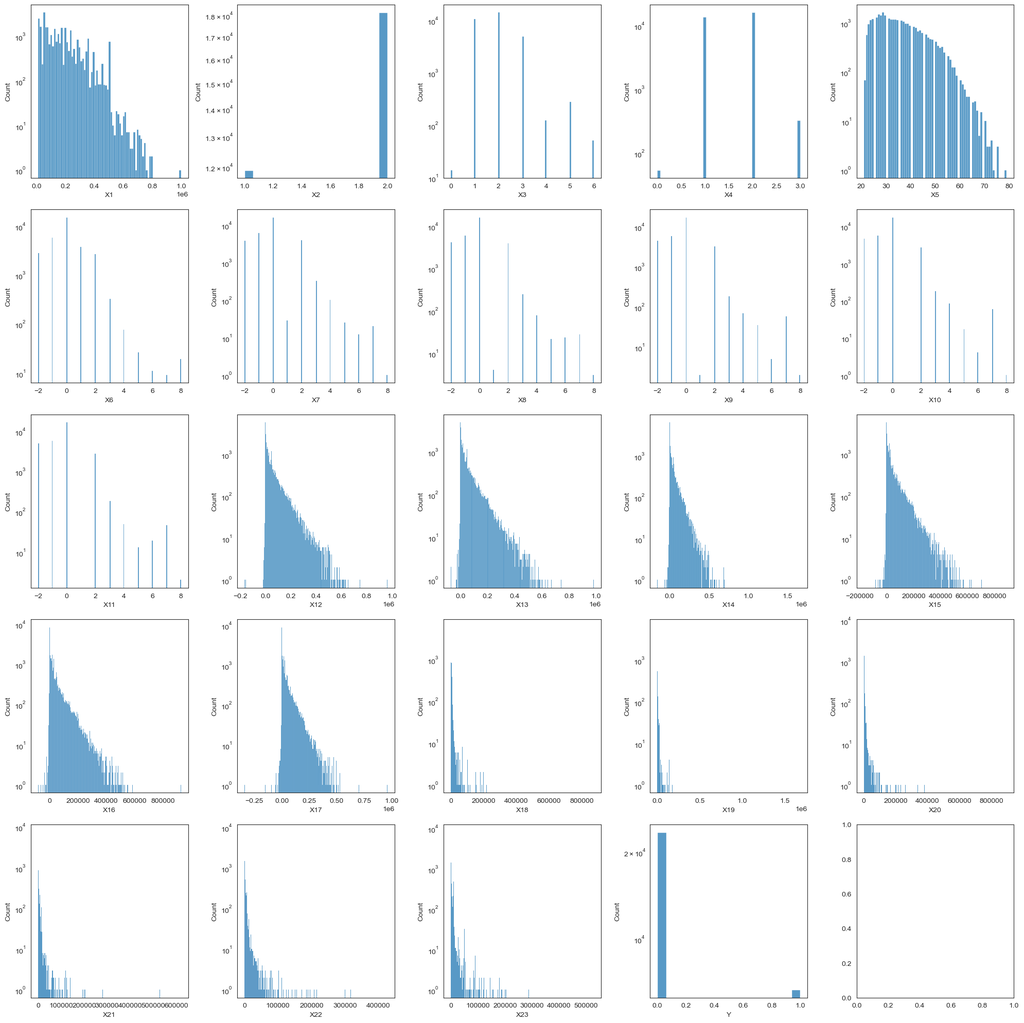

```python
fig, axs = plt.subplots(5,5, layout = "tight", figsize = (20,20))
import math

for i, column in enumerate(full_df.columns):
    sns.histplot(x = full_df[column], ax = axs[math.floor(i/5), i%5], log = True)
```

# 4. Implementation of Algorithm

In this section, I will be implementing three algorithms from scratch, and one algorithm from Scikit-learn. The three classification algorithms crafted from scratch are - k-NN, Naïve Bayes and Logistic Regression. The final algorithm from Scikit-learn is a Decision Tree Classifier.

```python
"""
Libraries used to build and evaluate the Machine Learning algorithms.
"""
import plotly.express as px  # plotly express to create interactive charts

from sklearn.metrics import f1_score, accuracy_score, precision_score, recall_score, roc_auc_score
from sklearn.metrics import confusion_matrix, ConfusionMatrixDisplay
from sklearn.model_selection import GridSearchCV, KFold, cross_validate, cross_val_score
from sklearn.utils.multiclass import unique_labels

from scipy.stats import mode # mode method returns an array of the most common values
from sklearn import tree # tree class for Decision Tree Classifier
from collections import Counter # supports convenient and rapid talles

# BaseEstimator is the base class and inheritance provides default implementations of estimators in scikit-learn
# ClassifierMixin provides the score method and enforces fit to require y

from sklearn.base import BaseEstimator, ClassifierMixin


from sklearn.naive_bayes import GaussianNB
from sklearn.decomposition import PCA # to perform principal component analysis
from sklearn.manifold import TSNE # to perform TSNE
from sklearn.preprocessing import PolynomialFeatures
```

```python
y.shape # find the shape of the labels
```

```
(30000, 1)
```

In order to judge the performance of our algorithms, we must establish a baseline model to set the standard for evaluation. The baseline model would provide a reference point, and help us measure how much value our custom models bring. For the purpose of this project, the baseline would be the fraction of the majority class.

As seen in Section 3, we have 23364 data points belonging to class 0 and 6636 belong to class 1. We calculate the baseline accuracy as the fraction of the count of the majority class over the total count of the data points.

```python
# Baseline
baseline_accuracy = y.value_counts()[0] / y.count()

print(baseline_accuracy)
```

```
Y    0.7788
dtype: float64
```

Hence, the baseline accuracy will be 0.7788. For an algorithm to be meaningful, it must perform better than this baseline.

## 4.1 K-Nearest Neighbours (From Scratch)

In the code below, I will implement the K-Nearest Neighbours from scratch. KNN predicts the class of a data point based on the majority class among the 'k' nearest neighbours. It is distance-based, and can learn complex decision boundaries. The performance of this model depends on the 'k' chosen.

```python
class KNN_Scratch(BaseEstimator, ClassifierMixin):
    """
    This is the KNN classifier implemented from scratch. Inheriting from BaseEstimator and ClassifierMixin,
    we define the methods init, fit, pairwise and predict in the format that allows us to use
    Scikit-learn's libraries and helper functions.
    """
    def __init__(self, k = 3, distance_metric='euclidean'):
        """
        Initialises the model with a default k value of 3. The default distance metric used is euclidean.
        This class does not support other distance metrics.
        """
        self.classes_ = None
        self.k = k # get the number of neighbours initialised with the KNN instance
        self.distance_metric = distance_metric # get the distance metric

    def fit(self, X, y):
        """
        Fits the model with the training dataset. Initialises the X, y, classes and shape of the dataset.
        """
        self.X_train_ = X # fit the training data set
        self.y_train_ = y # fit the labels for the training dataset
        self.classes_ = unique_labels(y) # get the classes as y
        self.m, self.n = X_train.shape # get the shape of the data
        return self

    def pairwise(self, X, point):
        """
        Calculates the function between two points.
        """
        # using Euclidenan formula
        return np.sqrt(np.sum(np.square(point-X))) # this is the Euclidiean formula


    def predict(self, X):
        """
        Predict the class
        """
        # array to store predictions
        y_predictions = []

        m, n = X.shape # get the shape of the test dataset

        # for as many data points
        for i in range(m):

            # get the pairwise distances
            distances = self.pairwise(self.X_train_, X.iloc[i]).ravel()

            # get the indices of the first k closest distances
            nearest_indx = np.argsort(distances)[:self.k]

            # get the label of the nearest distances (x correspond to y)
            nearest_labels = (self.y_train_.iloc[nearest_indx])

            # compute majority using value counts - the majority class will be on the first index
            prediction = nearest_labels.value_counts().index[0]

            # if the prediction class is 1, store 1 as the predicted value. Otherwise, store 0.
            predicted_val = 1 if (prediction == 1) else 0
            y_predictions.append(predicted_val)

        # return the predictions as an array, to use during the testing stage
        return np.array(y_predictions)
```

```python
knn = KNN_Scratch(k=3, distance_metric = 'euclidean')
knn.fit(X_train_scaled, y_train)
predictions = knn.predict(X_test_scaled)
predictions_trained = knn.predict(X_train_scaled)

# F1 score, Accuracy score and ROC AUC score for the custom KNN on training data
custom_knn_f1_train = f1_score(y_train, predictions_trained, average='weighted', labels=np.unique(predictions_trained))
custom_knn_accuracy_train = accuracy_score(y_train, predictions_trained)
custom_knn_auc_train = roc_auc_score(y_train, predictions_trained)

# F1 score for the custom KNN
custom_knn_f1 = f1_score(y_test, predictions, average='weighted', labels=np.unique(predictions))

# Accuracy score for the custom KNN
custom_knn_accuracy = accuracy_score(y_test, predictions)

# ROC AUC score for the custom KNN
custom_knn_auc = roc_auc_score(y_test, predictions)

# print statements for training scores
print(f"F1 score for KNN from scratch (Training): {custom_knn_f1_train:.5f}")
print(f"Accuracy score for KNN from scratch(Training): {custom_knn_accuracy_train:.5f}")
print(f"ROC AUC score for KNN from scratch(Training): {custom_knn_auc_train:.5f}\n")

# print statements for testing scores
print(f"F1 score for KNN from scratch: {custom_knn_f1:.5f}")
print(f"Accuracy score for KNN from scratch: {custom_knn_accuracy:.5f}")
print(f"ROC AUC score for KNN from scratch: {custom_knn_auc:.5f}")
```

```
F1 score for KNN from scratch (Training): 0.87563
Accuracy score for KNN from scratch(Training): 0.77878
ROC AUC score for KNN from scratch(Training): 0.50000

F1 score for KNN from scratch: 0.87567
Accuracy score for KNN from scratch: 0.77883
ROC AUC score for KNN from scratch: 0.50000
```

```
<sklearn.metrics._plot.confusion_matrix.ConfusionMatrixDisplay at 0x3174c1a00>
```

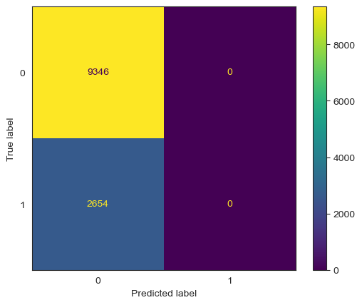

```python
matrix = confusion_matrix(y_test, predictions, labels=knn.classes_)
cm_display = ConfusionMatrixDisplay(confusion_matrix=matrix, display_labels=knn.classes_)
cm_display.plot()
```

### Summary of Custom KNN classifier

In the code block below, we implemented the KNN from scratch, with the number of k-neighbours set as 3. With this algorithm, we achieved a F1 score of 0.87566 and an Accuracy score of 0.77883. We can perform hyperparameter tuning to find the best k value using GridSearchCV.

### Fine-tuning for k-neighbours and distance metric with Grid Search

Reference: https://machinelearningknowledge.ai/knn-classifier-in-sklearn-using-gridsearchcv-with-example/

In the code block below, we will perform GridSearchCV on Scikit-learn's KNieghboursClassifer to tune find the best hyper-parameters.

```python
params = {
    'n_neighbors': [1,3,5,7,9],
    'metric' : ['euclidean', 'manhatten']
}
grid_knn = GridSearchCV(KNeighborsClassifier(), params, cv = 5, scoring = 'f1_weighted',return_train_score = True)

grid_knn.fit(X, y)

# best model
best = grid_knn.best_estimator_
best_params = grid_knn.best_params_
grid_knn_f1 = grid_knn.best_score_
```

```python
print(f'Best parameters for KNN: {grid_knn.best_params_['metric'], grid_knn.best_params_['n_neighbors']}')
print(f'Best score with GridSearchCV: {grid_knn.best_score_:.5f}')
```

```
Best parameters for KNN: ('euclidean', 5)
Best score with GridSearchCV: 0.72059
```

**Result of hyper-parameters tuning**

As seen above, the best parameters for Scikit-learn's KNN Classifier is a k value of 5 and euclidean as the distance metric. This gives us a F1 score of 0.72.

## 4.2 Naïve Bayes (From Scratch)

In the code below, I will implement the Naïve Bayes algorithm from scratch. Naïve Bayes uses Bayes' theorem with the assumption that features are independent.

```python
class NaiveBayes_Scratch(BaseEstimator, ClassifierMixin):
    """
    This is the Naive Bayes classifier implemented from scratch. Inheriting from BaseEstimator and ClassifierMixin,
    we define the methods init, fit, pairwise and predict in the format that allows us to use
    Scikit-learn's libraries and helper functions.
    """
    def __init__(self):
        """
        Initialises the Naive Bayes Classifier instance.
        """
        self.classes_ = None
        # priors refer to the probability of a class occuring before other information is taken into account
        self.priors = {}
        # stats dictionary will store means and variances for the label
        self.stats = {}

    def fit(self, X, y):
        """
        Fits the model with the training data, getting the prior probability, mean and variance.
        """
        # To find the unique classes - in this dataset, we expect two classes - 0 and 1
        self.classes_ = unique_labels(y)

        # Get the shape of the dataset
        Xm, Xn = X.shape

        # For each class, we have to calculate the mean, variances and priors
        # This allows us to get the bell curve for each class.

        for label in self.classes_:

            # filter for the data points that belong to the class (samples)
            X_class = X[y==label]

            # get the shape of the samples
            m, n = X_class.shape

            # get prior probability (samples in class divided by samples in total)
            self.priors[label] = m / Xm

            # get mean of samples
            means = np.mean(X_class, axis = 0)

            # get variance of samples
            variances = np.var(X_class, axis = 0)

            # store means as a dictionary
            self.stats[label] = {'means': means, 'variances': variances}

        return self

    # private function
    def _calculate_likelihood(self, x, mean, variance):
        """
        Calculate the log likelihood
        """
        exp = np.exp(-((x-mean)**2)/(2*variance))
        return (1/np.sqrt(2 * np.pi * variance)) * exp

    # get the list of probabilities
    def predict_probability(self, X):
        """
        Generate an array of the probabilities
        """
        # get probabilities as a list
        probabilities = []

        m, n = X.shape

        # for each instance
        for i in range(m):
            posteriors = {}

            # for each of the class
            for label in self.classes_:

                # get the log prior

                posterior = np.log(self.priors[label]) # initialise log likelihood

                # add log likelihood to each feature

                for j in range(n): # go through the features
                    mean = self.stats[label]['means'][j] # get the mean
                    variance = self.stats[label]['variances'][j] # get the variancec
                    # with mean and variance, get the posterior
                    posterior += np.log(self._calculate_likelihood(X.iloc[i][j], mean, variance))

                # the posterior for class 0 or class 1
                posteriors[label] = posterior

            # the code below is to normalise
            max_log = max(posteriors.values())
            # the exponent for the posteriors
            exponent_posteriors = {k: np.exp(v - max_log) for k, v in posteriors.items()}
            # get the sum of the exponents
            total = sum(exponent_posteriors.values())
            # get the log probabilities
            probabilities.append([exponent_posteriors[label]/ total for label in self.classes_])

        return np.array(probabilities) # return probabilities as an array

    def predict(self, X):
        """
        Get the maximum probability, based on the array of probabilities returned by predict_probability
        """
        probabilities = self.predict_probability(X)
        return np.argmax(probabilities, axis = 1) # get the class
```

```python
naivebayes = NaiveBayes_Scratch()
naivebayes.fit(X_train_scaled, y_train)
predictions = naivebayes.predict(X_test_scaled)
predictions_trained = naivebayes.predict(X_train_scaled)

# F1, Accuracy and ROC scores for the custom Naive Bayes on the training dataset
custom_naivebayes_f1_train = f1_score(y_train, predictions_trained, average='weighted', labels=np.unique(predictions_trained))
custom_naivebayes_accuracy_train = accuracy_score(y_train, predictions_trained)
custom_naivebayes_auc_train = roc_auc_score(y_train, predictions_trained)

# F1 score for the custom Naive Bayes
custom_naivebayes_f1 = f1_score(y_test, predictions, average='weighted', labels=np.unique(predictions))

# Accuracy score for the custom Naive Bayes
custom_naivebayes_accuracy = accuracy_score(y_test, predictions)

# ROC AUC score for the custom Naive Bayes
custom_naivebayes_auc = roc_auc_score(y_test, predictions)

# Print statements for training data
print(f"F1 score for Naive Bayes from scratch (Training): {custom_naivebayes_f1_train:.5f}")
print(f"Accuracy score for Naive Bayes from scratch (Training): {custom_naivebayes_accuracy_train:.5f}")
print(f"ROC AUC score for Naive Bayes from scratch (Training): {custom_naivebayes_auc_train:.5f}\n")

# Print statements for testing data
print(f"F1 score for Naive Bayes from scratch: {custom_naivebayes_f1:.5f}")
print(f"Accuracy score for Naive Bayes from scratch: {custom_naivebayes_accuracy:.5f}")
print(f"ROC AUC score for Naive Bayes from scratch: {custom_naivebayes_auc:.5f}")
```

```
F1 score for Naive Bayes from scratch (Training): 0.87563
Accuracy score for Naive Bayes from scratch (Training): 0.77878
ROC AUC score for Naive Bayes from scratch (Training): 0.50000

F1 score for Naive Bayes from scratch: 0.87567
Accuracy score for Naive Bayes from scratch: 0.77883
ROC AUC score for Naive Bayes from scratch: 0.50000
```

```
<sklearn.metrics._plot.confusion_matrix.ConfusionMatrixDisplay at 0x1757b1430>
```

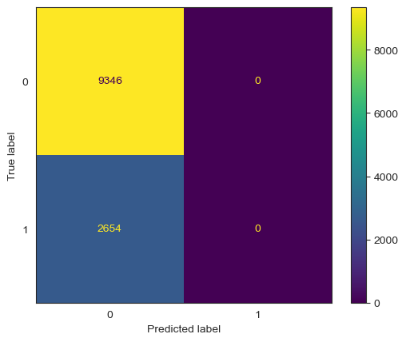

```python
matrix = confusion_matrix(y_test, predictions, labels=naivebayes.classes_)
cm_display = ConfusionMatrixDisplay(confusion_matrix=matrix, display_labels=naivebayes.classes_)
cm_display.plot()
```

### Summary of Custom Naive Bayes Classifier

As seen above, the F1 score for Naive Bayes from scratch reached 0.87566, which is on par with our custom KNN Classifier from scratch.

In the section below, we will use KFold and Cross_Validate from the Scikit-learn library to perform cross validation. We will be using f1 and accuracy as the metrics for the cross validation scores.

```python
k_fold = KFold(n_splits = 5, shuffle = True, random_state = 42)
scoring = ['f1_weighted','f1_micro','f1_macro','accuracy']
custom_nb_kf_scores = cross_validate(NaiveBayes_Scratch(), X, y, scoring = scoring,error_score="raise")
```

```python
for score in custom_nb_kf_scores:
    print(f'{score}: {np.mean(custom_nb_kf_scores[score]):.5f}')
```

```
fit_time: 0.05592
score_time: 6.68533
test_f1_weighted: 0.68195
test_f1_micro: 0.77880
test_f1_macro: 0.43782
test_accuracy: 0.77880
```

The mean cross validated scores are 0.68193. This is a poorer performance than the KNN Classifier. This may be because Naive Bayes relies on Bayes' theorem and assumes independence among the features. In addition, KNN can achieve more complex decision boundaries.

# 4.3 Logistic Regression (From Scratch)

In the code bellow, I will implement logistic regression from scratch. Logistic regression predicts the class of a data point using a sigmoid function. It assumes a linear relationship between the class and the features.

```python
import numpy as np
from scipy.special import expit # sigmoid
from sklearn.base import BaseEstimator, ClassifierMixin

class LogRegressor_Scratch(BaseEstimator, ClassifierMixin):
    """
    This is the Logistic Regression classifier implemented from scratch. Inheriting from BaseEstimator and ClassifierMixin,
    we define the methods init, fit, pairwise and predict in the format that allows us to use
    Scikit-learn's libraries and helper functions.
    """
    def __init__(self, learning_rate = 0.01, max_iterations = 10000, tolerance = 1e-6):
        """"
        Initialises the model
        """
        self.learning_rate = learning_rate
        self.max_iterations = max_iterations
        self.tolerance = tolerance
        self.weights = None
        self.classes_ = None

    def fit(self, X, y):
        """
        Fit the model with the training data. Get the weights using gradient descent.
        """
        # To find the unique classes - in this dataset, we expect two classes - 0 and 1
        self.classes_ = unique_labels(y)

        # add bias term
        self.classes_ = np.unique(y)
        X = np.hstack([np.ones((X.shape[0],1)),X])

        # initialise weights
        self.weights = np.zeros((X.shape[1],1))

        # reshape y
        y = y.values.reshape(-1,1)

        # perform gradient descent
        self.weights = self.gradient_descent(
            X, y, self.weights, self.learning_rate, self.max_iterations, self.tolerance
        )
        return self

    def predict_proba(self, X):
        """
        Return an array of the probabilities
        """
        # add bias term
        X = np.hstack([np.ones((X.shape[0],1)),X])
        # compute probabilities
        probabilities = expit(X @ self.weights)
        return np.hstack([1 - probabilities, probabilities])

    def predict(self,X):
        """
        Predict the class
        """
        # class labels
        probabilities = self.predict_proba(X)[:,1]
        return (probabilities >= 0.5).astype(int) # True or False, computed to int for Class 0 or 1

    def compute_gradient(self, X, y, weights):
        """
        Calculate the gradient with the logistic sigmoid function
        """
        # expit uses the sigmoid function
        predictions = expit(X @ weights) # perform matrix multiplication with X and the weights
        gradients = X.T @ (predictions - y) / X.shape[0] # matrix multiplication with transpose of X

        return gradients

    def gradient_descent(self,X, y, weights, learning_rate, max_iterations, tolerance):
        """
        Perform gradient descent and return the weights after either converging or reaching the max iterations
        """
        for iteration in range(max_iterations):
            gradients = self.compute_gradient(X, y, weights)
            weights = weights - learning_rate * gradients

            # checking for convergence
            if np.linalg.norm(gradients) < tolerance:
                print(f"converged after {iteration} iterations")
                break
        return weights
```

```python
logres = LogRegressor_Scratch()
logres.fit(X_train_scaled, y_train)
predictions = logres.predict(X_test_scaled)
predictions_trained = logres.predict(X_train_scaled)

# F1 score for the custom Logistic Regressor
custom_logres_f1 = f1_score(y_test, predictions, average='weighted', labels=np.unique(predictions))

# Accuracy score for the custom Logistic Regressor
custom_logres_accuracy = accuracy_score(y_test, predictions)

# ROC AUC score for the custom Logistic Regressor
custom_logres_auc = roc_auc_score(y_test, predictions)

# F1, Accuracy and AUC scores for the training data
custom_logres_f1_train = f1_score(y_train, predictions_trained, average='weighted', labels=np.unique(predictions_trained))
custom_logres_accuracy_train = accuracy_score(y_train, predictions_trained)
custom_logres_auc_train = roc_auc_score(y_train, predictions_trained)

# print statement for the training data
print(f"F1 score for Logistic Regression from scratch (Training): {custom_logres_f1_train:.5f}")
print(f"Accuracy score for Logistic Regression from scratch (Training): {custom_logres_accuracy_train:.5f}")
print(f"ROC AUC score for Logistic Regression from scratch (Training): {custom_logres_auc_train:.5f}\n")

# print statement for the scores
print(f"F1 score for Logistic Regression from scratch: {custom_logres_f1:.5f}")
print(f"Accuracy score for Logistic Regression from scratch: {custom_logres_accuracy:.5f}")
print(f"ROC AUC score for Logistic Regression from scratch: {custom_naivebayes_auc:.5f}")
```

```
F1 score for Logistic Regression from scratch (Training): 0.77759
Accuracy score for Logistic Regression from scratch (Training): 0.81406
ROC AUC score for Logistic Regression from scratch (Training): 0.61470

F1 score for Logistic Regression from scratch: 0.76860
Accuracy score for Logistic Regression from scratch: 0.80767
ROC AUC score for Logistic Regression from scratch: 0.50000
```

```
<sklearn.metrics._plot.confusion_matrix.ConfusionMatrixDisplay at 0x3210b84a0>
```

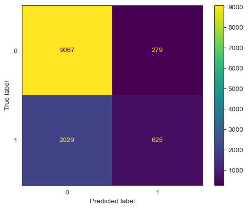

```python
matrix = confusion_matrix(y_test, predictions, labels=logres.classes_)
cm_display = ConfusionMatrixDisplay(confusion_matrix=matrix, display_labels=logres.classes_)
cm_display.plot()
```

### 5-fold cross validation with Cross_Val_Sore

In order to test the model's ability in predicting new data, we perform cross-validation. The Cross_Val_Score helper function splits the dataset into 5 folds by default and build a model for each fold. By checking the performance of the model on each fold, we can evaluate how well the model works on unseen data.

```python
logres_cross_val = cross_val_score(LogRegressor_Scratch(),X, y, scoring = 'f1_weighted', error_score = 'raise')
logres_cross_val
```

```
array([0.68177111, 0.68199909, 0.68199909, 0.68199909, 0.68199909])
```

## 4.4 Decision Tree (Scikit-Learn)

In this section, I will implement the DecisionTreeClassifier from Scikit-learn's Tree library. It uses a tree structure to classify the data points. By setting the class weight to balanced, the Decision Tree Classifier sets the weights to be inversely proportionate to the frequencies of each class.

```python
clf = tree.DecisionTreeClassifier(class_weight = "balanced")
clf = clf.fit(X_train_scaled,y_train)
predictions = clf.predict(X_test_scaled)
predictions_train = clf.predict(X_train_scaled)

# F1 score for the Decision Tree
decision_tree_f1 = f1_score(y_test, predictions)

# Accuracy score for the Decision Tree
decision_tree_accuracy = accuracy_score(y_test, predictions)

# ROC AUC score for the Decision Tree
decision_tree_auc = roc_auc_score(y_test, predictions)

# F1 score for the Decision Tree
decision_tree_f1_train = f1_score(y_train, predictions_train)

# Accuracy score for the Decision Tree
decision_tree_accuracy_train = accuracy_score(y_train, predictions_train)

# ROC AUC score for the Decision Tree
decision_tree_auc_train = roc_auc_score(y_train, predictions_train)

print(f"F1 score for Decision Tree (Train): {decision_tree_f1_train:.5f}")
print(f"Accuracy score for Decision Tree (Train): {decision_tree_accuracy_train:.5f}")
print(f"ROC AUC score for Decision Tree (Train): {decision_tree_auc_train:.5f}")
print(f"F1 score for Decision Tree: {decision_tree_f1:.5f}")
print(f"Accuracy score for Decision Tree: {decision_tree_accuracy:.5f}")
print(f"ROC AUC score for Decision Tree: {decision_tree_auc:.5f}")
```

```
F1 score for Decision Tree (Train): 0.99862
Accuracy score for Decision Tree (Train): 0.99939
ROC AUC score for Decision Tree (Train): 0.99961
F1 score for Decision Tree: 0.38086
Accuracy score for Decision Tree: 0.73042
ROC AUC score for Decision Tree: 0.60314
```

```python
X_train.shape, X_test.shape
```

```
((18000, 23), (12000, 23))
```

```
<sklearn.metrics._plot.confusion_matrix.ConfusionMatrixDisplay at 0x3210a0170>
```

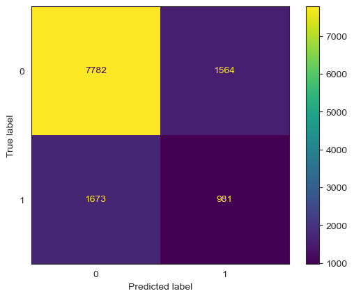

```python
matrix = confusion_matrix(y_test, predictions, labels=clf.classes_)
cm_display = ConfusionMatrixDisplay(confusion_matrix=matrix, display_labels=clf.classes_)
cm_display.plot()
```

# 5. Feature Engineering

## 5.1 Principal Component Analysis (PCA)

PCA is used to reduce the number of dimensions to principal components that retain most of the original information, by transforming correlated variables into a smaller set of features (principal components)

```python
pca = PCA() # initialise PCA
pca.fit(X_train_scaled) # Fit with the scaled training data
Xp_train = pca.transform(X_train_scaled) # Transform the scaled training data
Xp_test = pca.transform(X_test_scaled) # Transform the scaled testing data

nb_model = GaussianNB()
nb_model.fit(Xp_train,y_train)
predictions = nb_model.predict(Xp_test)

# F1 score for the Decision Tree
nb_pca_f1 = f1_score(y_test, predictions)

# Accuracy score for the Decision Tree
nb_pca_accuracy = accuracy_score(y_test, predictions)

# ROC AUC score for the Decision Tree
nb_pca_auc = roc_auc_score(y_test, predictions)
```

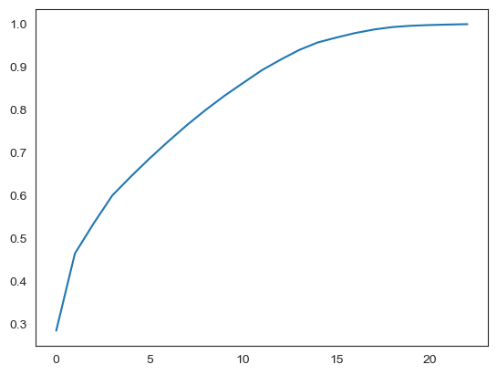

```python
plt.plot(np.cumsum(pca.explained_variance_ratio_))
```

```python
pca.explained_variance_
```

```
array([6.55752052, 4.14198358, 1.60869028, 1.50411086, 1.02106891,
       0.96944467, 0.91509601, 0.87498664, 0.81188373, 0.75416253,
       0.69016914, 0.68047889, 0.56507991, 0.52289563, 0.40562259,
       0.26186693, 0.2419758 , 0.18731919, 0.13205484, 0.07028363,
       0.03853399, 0.02595118, 0.02009839])
```

According to Kaiser rule when selecting the number of principal components to keep, we have to keep components with eigenvalues greater than 1. Hence, we will keep the number of components as 5.

```python
pca = PCA(n_components = 5)
pca.fit(X_train_scaled)
Xp_train = pca.transform(X_train_scaled)
Xp_test = pca.transform(X_test_scaled)
```

```python
Xp_train.shape, Xp_test.shape
```

```
((18000, 5), (12000, 5))
```

```python
Xp_train.shape, y_train.shape
```

```
((18000, 5), (18000, 1))
```

```python
k_fold = KFold(n_splits = 5, shuffle = True, random_state = 42)
knc = KNeighborsClassifier(n_neighbors = 5, metric = 'euclidean') # using the best parameters found earlier
knc.fit(Xp_train, y_train)
predictions = knc.predict(Xp_test)

# F1 score for the KNN classifier with 5 PCA components
knc_pca_f1 = f1_score(y_test, predictions)

# Accuracy score for the KNN classifier with 5 PCA components
knc_pca_accuracy = accuracy_score(y_test, predictions)

# ROC AUC score for the KNN classifier with 5 PCA components
knc_pca_auc = roc_auc_score(y_test, predictions)

print(f"F1 score for 5 PCA components: {knc_pca_f1:.5f}")
print(f"Accuracy score for 5 PCA components: {knc_pca_accuracy:.5f}")
print(f"ROC AUC score for 5 PCA components: {knc_pca_auc:.5f}")
```

```
F1 score for 5 PCA components: 0.37414
Accuracy score for 5 PCA components: 0.77975
ROC AUC score for 5 PCA components: 0.60716
```

```
<sklearn.metrics._plot.confusion_matrix.ConfusionMatrixDisplay at 0x3142d3620>
```

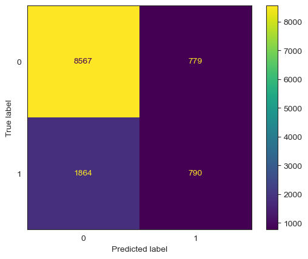

```python
matrix = confusion_matrix(y_test, predictions, labels=knc.classes_)
cm_display = ConfusionMatrixDisplay(confusion_matrix=matrix, display_labels=knc.classes_)
cm_display.plot()
```

## 5.2 TSNE

```python
tsne = TSNE(n_components=2, random_state=42)
X_train_tsne = tsne.fit_transform(X_train_scaled)
X_test_tsne = tsne.fit_transform(X_test_scaled)
tsne.kl_divergence_
```

```
1.343996286392212
```

```python
fig = px.scatter(x=X_train_tsne[:, 0], y=X_train_tsne[:, 1], color = y_train.values.ravel(),width=600, height=500)
fig.show()
```

[interactive chart not shown]

```python
k_fold = KFold(n_splits = 5, shuffle = True, random_state = 42)
knc = KNeighborsClassifier(n_neighbors = 5, metric = 'euclidean')
knc.fit(X_train_tsne, y_train)
predictions = knc.predict(X_test_tsne)

# F1 score for the KNN classifier with TSNE
knc_tsne_f1 = f1_score(y_test, predictions)

# Accuracy score for the KNN classifier with TSNE
knc_tsne_accuracy = accuracy_score(y_test, predictions)

# ROC AUC score for the KNN classifier with TSNE
knc_tsne_auc = roc_auc_score(y_test, predictions)

print(f"F1 score for 2 t-SNE components: {knc_tsne_f1:.5f}")
print(f"Accuracy score for 2 t-SNE components: {knc_tsne_accuracy:.5f}")
print(f"ROC AUC score for2 t-SNE components: {knc_tsne_auc:.5f}")
```

[output not shown]

## 5.3 Polynomial Features

|  | 1 | 2 | 3 |
| --- | --- | --- | --- |
| f1 | 0.351 | 0.428 | 0.432 |
| accuracy | 0.808 | 0.812 | 0.812 |
| roc_auc | 0.603 | 0.635 | 0.637 |
| matrix | [[9068, 278], [2029, 625]] | [[8899, 447], [1809, 845]] | [[8885, 461], [1795, 859]] |
| features_number | 24 | 300 | 2600 |

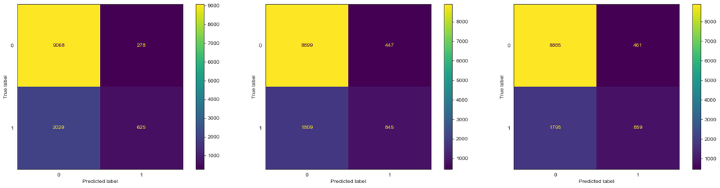

```python
scores = {}

fig, axs = plt.subplots(1,3, layout = "tight", figsize = (20,5))

for degree in range(1,4):
    poly = PolynomialFeatures(degree = degree)
    Xp_train = poly.fit_transform(X_train_scaled)
    Xp_test = poly.fit_transform(X_test_scaled)
    num_features = Xp_train.shape[1]
    # knc = KNeighborsClassifier(n_neighbors = 5, metric = 'euclidean')
    model = LogisticRegression()
    # knc.fit(Xp_train, y_train)
    model.fit(Xp_train, y_train)
    predictions = model.predict(Xp_test)

    features = Xp_train.shape[1]

    # F1 score for the KNN classifier with polynomial features
    pf_f1 = f1_score(y_test, predictions)

    # Accuracy score for the KNN classifier with polynomial features
    pf_accuracy = accuracy_score(y_test, predictions)

    # ROC AUC score for the KNN classifier with polynomial features
    pf_auc = roc_auc_score(y_test, predictions)

    pf_matrix = confusion_matrix(y_test, predictions, labels=model.classes_)
    cm_display = ConfusionMatrixDisplay(confusion_matrix=pf_matrix, display_labels=model.classes_)
    cm_display.plot(ax = axs[degree - 1])

    scores[degree] = {'f1': pf_f1,
                     'accuracy':pf_accuracy,
                     'roc_auc':pf_auc,
                     'matrix': pf_matrix,
                     'features_number': features}

pd.options.display.float_format = '{:,.3f}'.format
polynomial_scores = pd.DataFrame.from_dict(scores)
polynomial_scores
```

## 5.4 RFE

```python
from sklearn.feature_selection import RFE
from sklearn.linear_model import LogisticRegression

rfe_scores = {} # initialise empty dict

# new
logres = LogisticRegression()

for n in range(1,24):
    # rfe = RFE(estimator=LogisticRegression(), n_features_to_select=n)
    rfe = RFE(estimator = logres, n_features_to_select = n)
    rfe.fit(X_train_scaled, y_train)

    # Get the selected features
    selected_features = X_train_scaled.columns[rfe.support_]

    # create new training set
    # rfe.predict(X_test_scaled)
    # rfe.score(X_test_scaled, y_test
    X_train_rfe = X_train_scaled[selected_features]
    X_test_rfe = X_test_scaled[selected_features]

    logres.fit(X_train_rfe, y_train)
    predictions = logres.predict(X_test_rfe)

    # F1 score for the KNN classifier with polynomial features
    rfe_f1 = f1_score(y_test, predictions)

    # Accuracy score for the KNN classifier with polynomial features
    rfe_accuracy = accuracy_score(y_test, predictions)

    # ROC AUC score for the KNN classifier with polynomial features
    rfe_auc = roc_auc_score(y_test, predictions)

    rfe_scores[n] = {'f1': rfe_f1,
                     'accuracy':rfe_accuracy,
                     'roc_auc':rfe_auc,
                     'features_number': 24-n}


print(f"F1 score for rfe components: {rfe_f1:.5f}")
print(f"Accuracy score for rfe components: {rfe_accuracy:.5f}")
print(f"ROC AUC score for rfe components: {rfe_auc:.5f}")
```

```
F1 score for rfe components: 0.35188
Accuracy score for rfe components: 0.80783
ROC AUC score for rfe components: 0.60306
```

```python
pd.options.display.float_format = '{:,.3f}'.format
rfe_scores_df = pd.DataFrame.from_dict(rfe_scores)
rfe_scores_df.T
```

|  | f1 | accuracy | roc_auc | features_number |
| --- | --- | --- | --- | --- |
| 1 | 0.435 | 0.817 | 0.639 | 23.000 |
| 2 | 0.414 | 0.814 | 0.629 | 22.000 |
| 3 | 0.343 | 0.808 | 0.600 | 21.000 |
| 4 | 0.336 | 0.806 | 0.597 | 20.000 |
| 5 | 0.336 | 0.806 | 0.597 | 19.000 |
| 6 | 0.339 | 0.807 | 0.598 | 18.000 |
| 7 | 0.348 | 0.808 | 0.602 | 17.000 |
| 8 | 0.360 | 0.810 | 0.606 | 16.000 |
| 9 | 0.354 | 0.809 | 0.604 | 15.000 |
| 10 | 0.355 | 0.808 | 0.605 | 14.000 |
| 11 | 0.353 | 0.807 | 0.603 | 13.000 |
| 12 | 0.357 | 0.808 | 0.605 | 12.000 |
| 13 | 0.350 | 0.807 | 0.602 | 11.000 |
| 14 | 0.353 | 0.808 | 0.603 | 10.000 |
| 15 | 0.353 | 0.808 | 0.603 | 9.000 |
| 16 | 0.353 | 0.808 | 0.603 | 8.000 |
| 17 | 0.351 | 0.808 | 0.603 | 7.000 |
| 18 | 0.352 | 0.808 | 0.603 | 6.000 |
| 19 | 0.353 | 0.808 | 0.603 | 5.000 |
| 20 | 0.352 | 0.808 | 0.603 | 4.000 |
| 21 | 0.352 | 0.808 | 0.603 | 3.000 |
| 22 | 0.352 | 0.808 | 0.603 | 2.000 |
| 23 | 0.352 | 0.808 | 0.603 | 1.000 |